# Explore Text & Conduct Sentiment Analysis

# Get Data

## About the Data

This dataset is based on a set of Amazon review of video games downloaded from Prof Julian McAuley’s website (http://jmcauley.ucsd.edu/data/amazon/). The original json dataset was parsed into a dataframe and cleaned. Since this dataset is very large, I have only included data from Aug 2013 to July 2014 which gives us a year of data to work with. Also we are only using data on three fields, id, review and review rating. Finally, three blank reviews were dropped from the data. The data we are going to use includes the following fields:

- id: A unique identifier for each review
- review: Text of review posted on Amazon
- review_rating: Each review on Amazon is rated by others using a five-star scale (presumably based on helpfulness of review).

## Read in Reviews

You must read the data before trying to run code on your own machine. To read data use the following code after setting your working directory. To set your working directory, modify the following to set the file path for the folder where the data file resides. setwd(’c:/thatawesomeclass/)

```r
videogame = read.csv('video_game_reviews.csv',stringsAsFactors = F)
```

# Explore Text

### Structure of dataset

```r
str(videogame)
```

```
## 'data.frame':    26652 obs. of  3 variables:
##  $ id           : int  1 2 3 4 5 6 7 8 9 10 ...
##  $ review       : chr  "1st shipment received a book instead of the game.2nd shipment got a FAKE one. Game arrived with a wrong key ins"| __truncated__ "I still haven't figured this one out. Did everything as instructed but the game never installed. Strange. Since"| __truncated__ "I bought this a…
##  $ review_rating: int  1 2 1 5 5 1 5 5 5 5 ...
```

### Explore Ratings of Reviews

```r
median(videogame$review_rating) # median review rating
```

```
## [1] 5
```

```r
mean(videogame$review_rating) # mean review ratint
```

```
## [1] 4.194544
```

```r
# Using dplyr
library(dplyr)
videogame%>%
  summarize(average_rating = mean(review_rating), median_rating = median(review_rating))
```

| average_rating | median_rating |
| --- | --- |
| 4.194544 | 5 |

### Distribution of Reviews

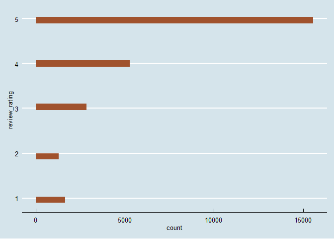

```r
library(ggplot2); library(ggthemes)
ggplot(data=videogame,aes(x=review_rating))+
  geom_histogram(fill='sienna')+
  theme_economist()+
  coord_flip()
```

### Let us examine a randomly selected review, 617

#### Number of characters

```r
videogame$review[617]
```

```
## [1] "Like scottrocket3 said, you're out of your damn mind if you buy this for $200.  This is the best Mario game that ever came out.  The other is Super Mario World for Super Nintendo, also available for Nintendo DS.  I can't say enough about this great game!!  I LOVED the Super Mario Brothers Su…
```

```r
nchar(videogame$review[617])
```

```
## [1] 717
```

#### Number of words in Review 617

```r
library(stringr)
str_count(string = videogame$review[617],pattern = '\\S+')
```

```
## [1] 127
```

#### Number of sentences in Review 617

Regular expressions (regex) is a framework for teaching a computer how to recognize patterns of text. Regex has a consistent implementation across many different programming languages and you can read more about it here: https://en.wikipedia.org/wiki/Regular_expression.

In order to count sentences, one needs to define what a sentence is. If we defined a sentence as “a set of characters or punctuation (comma, quote) or spaces that end with one or more period, question mark, exclamation mark or combination of them”, the following reqular expression would match the sentence: [A-Za-z,;’"\s]+[^.!?]*[.?!]

```r
str_count(string = videogame$review[617],pattern = "[A-Za-z,;'\"\\s]+[^.!?]*[.?!]")
```

```
## [1] 12
```

### Other nuggets

To get a bit personal here, my sons are minecraft addicts, so I was curious to see what % of reviews mention ‘minecraft’ in them. As you look at the results, keep in mind reviews are from 2013-14. Is there anything you are curious to find out about the reviews?

str_detect will only detect whether or not “minecraft” or “mine craft” are present in the reviews after converting all of them to lower case.

```r
mean(str_detect(string=tolower(videogame$review),pattern='minecraft|mine craft'))*100
```

```
## [1] 0.1913552
```

### Character, Words and Sentences for all Reviews

Number of characters, words or sentences in review 617 is hard to evaluate out of context. So, let us get some context by finding the mean and median across all reviews. Characters across all reviews.

```r
mean_char = mean(nchar(videogame$review)); mean_char
```

```
## [1] 673.4075
```

```r
median_char = median(nchar(videogame$review)); median_char
```

```
## [1] 270
```

#### Words across all reviews

```r
mean_words = mean(str_count(string = videogame$review,pattern = '\\S+')); mean_words
```

```
## [1] 123.3287
```

```r
median_words = median(str_count(string = videogame$review,pattern = '\\S+')); median_words
```

```
## [1] 51
```

#### Sentences across all reviews

```r
mean_sentences = mean(str_count(string = videogame$review,pattern = "[A-Za-z,;'\"\\s]+[^.!?]*[.?!]")); mean_sentences
```

```
## [1] 7.575116
```

```r
median_sentences = median(str_count(string = videogame$review,pattern = "[A-Za-z,;'\"\\s]+[^.!?]*[.?!]")); median_sentences
```

```
## [1] 4
```

#### Longest Review and Shortest Review

```r
summary(nchar(videogame$review))
```

```
##    Min. 1st Qu.  Median    Mean 3rd Qu.    Max.
##     3.0   142.0   270.0   673.4   667.0 24012.0
```

```r
summary(str_count(string = videogame$review,pattern = '\\S+'))
```

```
##    Min. 1st Qu.  Median    Mean 3rd Qu.    Max.
##     1.0    27.0    51.0   123.3   124.0  4467.0
```

```r
summary(str_count(string = videogame$review,pattern = "[A-Za-z,;'\"\\s]+[^.!?]*[.?!]"))
```

```
##    Min. 1st Qu.  Median    Mean 3rd Qu.    Max.
##   0.000   2.000   4.000   7.575   8.000 416.000
```

```r
longest_review_index = which.max(str_count(string = videogame$review,pattern = "[A-Za-z,;'\"\\s]+[^.!?]*[.?!]"))
videogame$review[longest_review_index]
```

```
## [1] "*****No Spoilers. I don't like them. Nobody likes them****** ****** I will update this thread whenever possible******The original Dark Souls was my favorite have I've played over the years in my life. the feel to it was great and it was a unique game. now that Dark Souls II was about to come…
```

### Review length and Ratings

Are longer reviews associated with better ratings? In other words, do people rate long reviews as being more helpful?

#### Review Length in characters

```r
cor(nchar(videogame$review),videogame$review_rating)
```

```
## [1] -0.08478651
```

```r
cor.test(nchar(videogame$review),videogame$review_rating)
```

```
##
##  Pearson's product-moment correlation
##
## data:  nchar(videogame$review) and videogame$review_rating
## t = -13.891, df = 26650, p-value < 2.2e-16
## alternative hypothesis: true correlation is not equal to 0
## 95 percent confidence interval:
##  -0.09669376 -0.07285499
## sample estimates:
##         cor
## -0.08478651
```

#### Review Length in words

```r
cor(str_count(string = videogame$review,pattern = '\\S+'),videogame$review_rating)
```

```
## [1] -0.08574868
```

```r
cor.test(str_count(string = videogame$review,pattern = '\\S+'),videogame$review_rating)
```

```
##
##  Pearson's product-moment correlation
##
## data:  str_count(string = videogame$review, pattern = "\\S+") and videogame$review_rating
## t = -14.05, df = 26650, p-value < 2.2e-16
## alternative hypothesis: true correlation is not equal to 0
## 95 percent confidence interval:
##  -0.09765382 -0.07381899
## sample estimates:
##         cor
## -0.08574868
```

#### Review Length in sentences

```r
cor(str_count(string = videogame$review,pattern = "[A-Za-z,;'\"\\s]+[^.!?]*[.?!]"),videogame$review_rating)
```

```
## [1] -0.09343258
```

```r
cor.test(str_count(string = videogame$review,pattern = "[A-Za-z,;'\"\\s]+[^.!?]*[.?!]"),videogame$review_rating)
```

```
##
##  Pearson's product-moment correlation
##
## data:  str_count(string = videogame$review, pattern = "[A-Za-z,;'\"\\s]+[^.!?]*[.?!]") and videogame$review_rating
## t = -15.32, df = 26650, p-value < 2.2e-16
## alternative hypothesis: true correlation is not equal to 0
## 95 percent confidence interval:
##  -0.10532012 -0.08151834
## sample estimates:
##         cor
## -0.09343258
```

### Screaming Reviews

How do you feel about people who scream in texts or email? What about screaming in reviews?  
Here we examine the proportion of upper case letters in a review.

```r
proportionUpper = str_count(videogame$review,pattern='[A-Z]')/nchar(videogame$review)
cor(proportionUpper,videogame$review_rating)
```

```
## [1] 0.01865663
```

```r
cor.test(proportionUpper,videogame$review_rating)
```

```
##
##  Pearson's product-moment correlation
##
## data:  proportionUpper and videogame$review_rating
## t = 3.0462, df = 26650, p-value = 0.00232
## alternative hypothesis: true correlation is not equal to 0
## 95 percent confidence interval:
##  0.006652443 0.030655447
## sample estimates:
##        cor
## 0.01865663
```

### Exclamation marks

In messaging, reviews and chat, we are allowed to break all rules of grammar like using a flood of exclamation marks. Does that tell us something?  
First, how common are exclamations?

```r
summary(str_count(videogame$review,pattern='!'))
```

```
##     Min.  1st Qu.   Median     Mean  3rd Qu.     Max.
##   0.0000   0.0000   0.0000   0.5415   0.0000 141.0000
```

Are reviews with exclamations rated as being more helpful?

```r
proportionExclamation = str_count(videogame$review,pattern='!')/nchar(videogame$review)
cor(proportionExclamation,videogame$review_rating)
```

```
## [1] 0.05558568
```

```r
cor.test(proportionUpper,videogame$review_rating)
```

```
##
##  Pearson's product-moment correlation
##
## data:  proportionUpper and videogame$review_rating
## t = 3.0462, df = 26650, p-value = 0.00232
## alternative hypothesis: true correlation is not equal to 0
## 95 percent confidence interval:
##  0.006652443 0.030655447
## sample estimates:
##        cor
## 0.01865663
```

### Most Common Words

Let us see which words are used most frequently in these reviews. For this we can use the freq_terms function from library(qdap).

Here we will list the top 25 frequently occuring words.

```r
library(qdap)
freq_terms(text.var = videogame$review,top = 25)
```

|  | WORD | FREQ |
| --- | --- | --- |
| 63900 | the | 175405 |
| 2931 | and | 92864 |
| 65512 | to | 87191 |
| 651 | a | 83946 |
| 31630 | i | 69042 |
| 44039 | of | 61927 |
| 33695 | is | 58974 |
| 33903 | it | 58635 |
| 25704 | game | 52648 |
| 72835 | you | 51359 |

[output cut: 15 more lines]

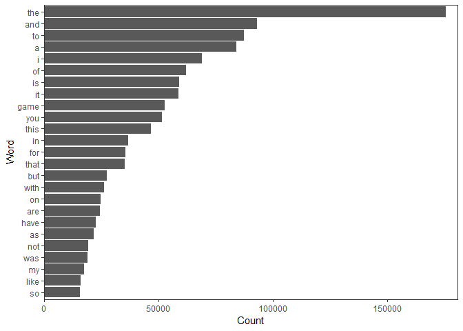

```r
plot(freq_terms(text.var = videogame$review,top = 25))
```

In case you have trouble installing qdap on a Mac, do the following  
* Update your mac to the latest version  
* Install JDK from https://www.oracle.com/technetwork/java/javase/downloads/jdk8-downloads-2133151.html  
* Run “sudo R CMD javareconf” in your terminal. If you don’t know how to open your terminal: https://www.youtube.com/watch?v=zw7Nd67_aFw  
* Restart Rstudio  
If it still doesn’t work: * Run “sudo ln -f -s $(/usr/libexec/java_home)/jre/lib/server/libjvm.dylib /usr/local/lib” in your terminal  
* Restart Rstudio

Perhaps, not surprisingly the list contains a lot of prepositions and articles and words that don’t convey much meaning. Such words are called stopwords. Let us look at the top25 list after removing the stopwords.

```r
freq_terms(text.var=videogame$review,top=25,stopwords = Top200Words)
```

|  | WORD | FREQ |
| --- | --- | --- |
| 25704 | game | 52648 |
| 26265 | games | 14773 |
| 33908 | it's | 12066 |
| 51948 | really | 9311 |
| 25288 | fun | 8432 |
| 50523 | ps | 7329 |
| 18093 | don't | 6068 |
| 61134 | story | 6068 |
| 48316 | playing | 5460 |
| 6601 | better | 5010 |

[output cut: 15 more lines]

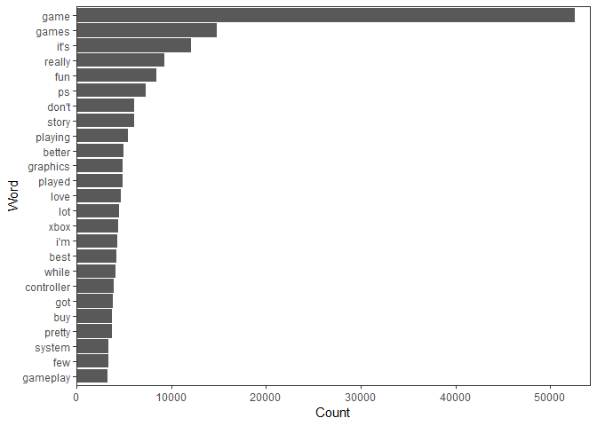

```r
plot(freq_terms(text.var=videogame$review,top=25,stopwords = Top200Words))
```

### Words that make a review useful

Which words are most likely to tied to reviews rated as being helpful?

For this, I have dropped the top200 stopwords and some words that initial analysis found to occur across all review ratings. Such words have little diagnostic value.

```r
words_by_rating = word_list(videogame$review,
                            grouping.var=tolower(videogame$review_rating),
                            stopwords = c(Top200Words,"game","games","playing","it's","i've","i'm"),
                            cut.n = 25)
print(words_by_rating)
```

```
## $`1`
##          WORD FREQ
## 1       don't  504
## 2          ps  398
## 3      really  371
## 4         buy  365
## 5         bad  302
## 6       money  298
## 7         got  293
## 8      better  287
## 9        xbox  287
## 10      can't  275
## 11   graphics  266
## 12 controller  264
## 13      never  260
```

[output cut: 125 more lines]

# Tokenize

Let us classify the words to gain a better understanding of the reviews. For this, we will use the dplyr and tidytext packages. We will make use of the unnest_tokens function from tidytext to tokenize the reviews and the following dplyr functions to organize the data: select, group_by, ungroup and count. Later on, we will also use the tidyr package to reshape the data.

### Words in Reviews

Let us begin by counting the number of words in each review.

```r
library(dplyr); library(tidytext)
videogame %>%
  select(id,review)%>%
  group_by(id)%>%
  unnest_tokens(output = word,input=review)%>%
  ungroup()%>%
  group_by(id)%>%
  summarize(count = n())
```

| id | count |
| --- | --- |
| 1 | 54 |
| 2 | 80 |
| 3 | 37 |
| 4 | 20 |
| 5 | 37 |
| 6 | 949 |
| 7 | 47 |
| 8 | 8 |
| 9 | 19 |
| 10 | 21 |

[output cut: 9990 more lines]

### Total words

So, what is the total number of words in all reviews?

```r
videogame %>%
  select(id,review)%>%
  group_by(id)%>%
  unnest_tokens(output = word,input=review)%>%
  ungroup()%>%
  count()   # count is a shortcut to summarize used above
```

| n |
| --- |
| 3326753 |

# Categorize Tokens - Summarize

One of the simplest approaches to natural language processing is to use a bag of words approach where each token is mapped to a characteristic from a lexicon. For instance, a token such as “horrible” may be compared to a lexicon that categorizes words as “good/bad” and assigned a characteristic of “bad”

A lexicon is a taxonomy of tokens. There are a wide variety of lexicons available. Choice of lexicon will vary based on the goal of the analysis.

## Binary Sentiment (positive/negative) Lexicons

These lexicons use a simple approach of classifying tokens into two categories, usually positive or negative. One common lexicon for doing so is ‘bing’

## Bing Lexicon

The bing lexicon categorizes words as being positive and negative. Here are the first fifty words.

```r
as.data.frame(get_sentiments('bing'))[1:50,]
```

|  | word | sentiment |
| --- | --- | --- |
| 1 | 2-faced | negative |
| 2 | 2-faces | negative |
| 3 | a+ | positive |
| 4 | abnormal | negative |
| 5 | abolish | negative |
| 6 | abominable | negative |
| 7 | abominably | negative |
| 8 | abominate | negative |
| 9 | abomination | negative |
| 10 | abort | negative |

[output cut: 40 more lines]

```r
get_sentiments('bing')%>%
  group_by(sentiment)%>%
  count()
```

| sentiment | n |
| --- | --- |
| negative | 4782 |
| positive | 2006 |

Now, let us explore valence of the words used in reviews using the bing dictionary. We will match the words in the dictionary with the ones in the reviews to determine valence.

```r
videogame%>%
  group_by(id)%>%
  unnest_tokens(output = word, input = review)%>%
  inner_join(get_sentiments('bing'))%>%
  group_by(sentiment)
```

| id | review_rating | word | sentiment |
| --- | --- | --- | --- |
| 1 | 1 | fake | negative |
| 1 | 1 | wrong | negative |
| 1 | 1 | fake | negative |
| 1 | 1 | good | positive |
| 2 | 2 | strange | negative |
| 2 | 2 | like | positive |
| 2 | 2 | work | positive |
| 2 | 2 | like | positive |
| 2 | 2 | work | positive |
| 2 | 2 | great | positive |

[output cut: 9990 more lines]

### Positive and Negative Words in Reviews

Let’s find out the total number of positive and negative words in the reviews.

```r
videogame%>%
  group_by(id)%>%
  unnest_tokens(output = word, input = review)%>%
  inner_join(get_sentiments('bing'))%>%
  group_by(sentiment)%>%
  count()
```

| sentiment | n |
| --- | --- |
| negative | 93996 |
| positive | 172806 |

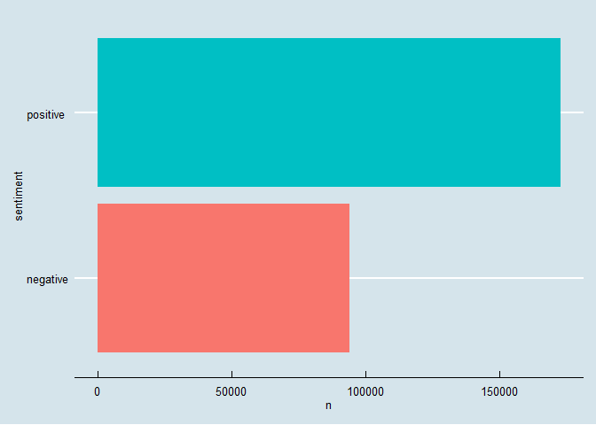

```r
videogame%>%
  group_by(id)%>%
  unnest_tokens(output = word, input = review)%>%
  inner_join(get_sentiments('bing'))%>%
  group_by(sentiment)%>%
  count()%>%
  ggplot(aes(x=sentiment,y=n,fill=sentiment))+geom_col()+theme_economist()+guides(fill=F)+
  coord_flip()
```

### Proportion of Positive words in Reviews

So, what proportion of words in reviews are positive. It may be much easier to punch in the numbers from the above table into a calculator.Nevertheless, here is the code to do the whole thing.

```r
videogame %>%
  select(id,review)%>%
  group_by(id)%>%
  unnest_tokens(output=word,input=review)%>%
  ungroup()%>%
  inner_join(get_sentiments('bing'))%>%
  group_by(sentiment)%>%
  summarize(n = n())%>%
  mutate(proportion = n/sum(n))
```

| sentiment | n | proportion |
| --- | --- | --- |
| negative | 93996 | 0.3523062 |
| positive | 172806 | 0.6476938 |

### Positive Review, helpful?

Let us drill down a bit more to see if reviews that have a lot of positive words are rated as helpful.

```r
videogame %>%
  select(id,review,review_rating)%>%
  group_by(id)%>%
  unnest_tokens(output=word,input=review)%>%
  ungroup()%>%
  inner_join(get_sentiments('bing'))%>%
  group_by(review_rating,sentiment)%>%
  summarize(n = n())%>%
  mutate(proportion = n/sum(n))
```

| review_rating | sentiment | n | proportion |
| --- | --- | --- | --- |
| 1 | negative | 9104 | 0.5578431 |
| 1 | positive | 7216 | 0.4421569 |
| 2 | negative | 9051 | 0.5029451 |
| 2 | positive | 8945 | 0.4970549 |
| 3 | negative | 15186 | 0.4214821 |
| 3 | positive | 20844 | 0.5785179 |
| 4 | negative | 23600 | 0.3567703 |
| 4 | positive | 42549 | 0.6432297 |
| 5 | negative | 37055 | 0.2843669 |
| 5 | positive | 93252 | 0.7156331 |

and in pictures.

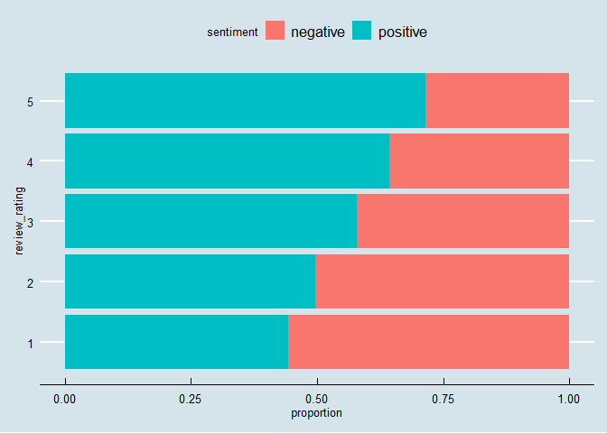

```r
videogame %>%
  select(id,review,review_rating)%>%
  group_by(id)%>%
  unnest_tokens(output=word,input=review)%>%
  ungroup()%>%
  inner_join(get_sentiments('bing'))%>%
  group_by(review_rating,sentiment)%>%
  summarize(n = n())%>%
  mutate(proportion = n/sum(n))%>%
  ggplot(aes(x=review_rating,y=proportion,fill=sentiment))+geom_col()+theme_economist()+coord_flip()
```

### Fraction of Positive Words

Let us compute a fraction of positive words and all positive and negative words for each review

```r
videogame%>%
  group_by(id)%>%
  unnest_tokens(output = word, input = review)%>%
  inner_join(get_sentiments('bing'))%>%
  group_by(id)%>%
  summarize(positivity = sum(sentiment=='positive')/n())
```

| id | positivity |
| --- | --- |
| 1 | 0.25000000 |
| 2 | 0.50000000 |
| 3 | 0.50000000 |
| 4 | 1.00000000 |
| 5 | 1.00000000 |
| 6 | 0.37349398 |
| 7 | 0.25000000 |
| 8 | 0.66666667 |
| 9 | 1.00000000 |
| 10 | 1.00000000 |

[output cut: 9990 more lines]

### Correlation between Positive Words and Review helpfulness

Let us see if reviews with a lot of positive words are rated favorably.

```r
videogame%>%
  group_by(id)%>%
  unnest_tokens(output = word, input = review)%>%
  inner_join(get_sentiments('bing'))%>%
  group_by(id,review_rating)%>%
  summarize(positivity = sum(sentiment=='positive')/n())%>%
  ungroup()%>%
  summarize(correlation = cor(positivity,review_rating))
```

| correlation |
| --- |
| 0.4023517 |

## NRC Sentiment Polarity Table - Lexicon

This is another binary sentiment lexicon that categorizes words as +1 or -1

```r
library(lexicon)
head(hash_sentiment_nrc)
```

| x | y |
| --- | --- |
| abandon | -1 |
| abandoned | -1 |
| abandonment | -1 |
| abba | 1 |
| abduction | -1 |
| aberrant | -1 |

```r
hash_sentiment_nrc %>%
  group_by(y)%>%
  summarize(count= n())
```

| y | count |
| --- | --- |
| -1 | 3241 |
| 1 | 2227 |

Since lexicons vary by number of words covered and manner of classification, results will vary by lexicon.

```r
videogame %>%
  select(id, review)%>%
  group_by(id)%>%
  unnest_tokens(output = word, input = review)%>%
  inner_join(y = hash_sentiment_nrc,by = c('word'='x'))%>%
  ungroup()%>%
  group_by(y)%>%
  summarize(count = n())%>%
  ungroup()
```

| y | count |
| --- | --- |
| -1 | 88608 |
| 1 | 152018 |

## Emotion Lexicon

This lexicon categorizes words based on the emotion conveyed. Rather than grouping words as positive or negative, words are categorized based on the emotion reflected. Furthermore, a single word may reflect multiple emotions.

## NRC Emotion Lexicon

A word may reflect more than just valence. The ‘nrc’ lexicon categorizes words by emotion. This lexicon which was previously a part of library(tidytext) was dropped from the package as of June 14, 2019. The lexicon was copied from its non-commercial use link and posted github. This lexicon and a number of others can be found at http://sentiment.nrc.ca/lexicons-for-research/ but its use for free can only be for non-commercial purposes. The following code will place the lexicon in a dataframe called nrc.

```r
nrc = read.table(file = 'https://raw.githubusercontent.com/pseudorational/data/master/nrc_lexicon.txt',header = F,col.names = c('word','sentiment','num'),sep = '\t'); nrc = nrc[nrc$num!=0,]; nrc$num = NULL
```

Here is a list of emotions covered by this lexicon.

```r
nrc%>%
  group_by(sentiment)%>%
  count()
```

| sentiment | n |
| --- | --- |
| anger | 1247 |
| anticipation | 839 |
| disgust | 1058 |
| fear | 1476 |
| joy | 689 |
| negative | 3324 |
| positive | 2312 |
| sadness | 1191 |
| surprise | 534 |
| trust | 1231 |

```r
table(nrc$sentiment)
```

```
##
##        anger anticipation      disgust         fear          joy
##         1247          839         1058         1476          689
##     negative     positive      sadness     surprise        trust
##         3324         2312         1191          534         1231
```

### Emotions in Reviews

Let us examine the emotions expressed in the reviews

```r
videogame%>%
  group_by(id)%>%
  unnest_tokens(output = word, input = review)%>%
  inner_join(nrc)%>%
  group_by(sentiment)%>%
  count()
```

| sentiment | n |
| --- | --- |
| anger | 45833 |
| anticipation | 83399 |
| disgust | 24478 |
| fear | 52559 |
| joy | 72826 |
| negative | 91605 |
| positive | 157200 |
| sadness | 44438 |
| surprise | 36535 |
| trust | 85287 |

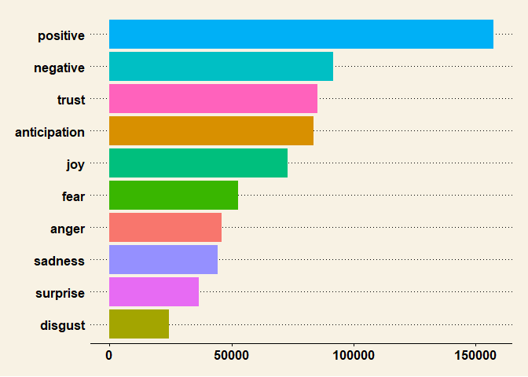

```r
videogame%>%
  group_by(id)%>%
  unnest_tokens(output = word, input = review)%>%
  inner_join(nrc)%>%
  group_by(sentiment)%>%
  count()%>%
  ggplot(aes(x=reorder(sentiment,X = n),y=n,fill=sentiment))+geom_col()+guides(fill=F)+coord_flip()+theme_wsj()
```

### Ratings of each Review based on Emotions Expressed

```r
videogame%>%
  group_by(id)%>%
  unnest_tokens(output = word, input = review)%>%
  inner_join(nrc)%>%
  group_by(id,sentiment,review_rating)%>%
  count()
```

| id | sentiment | review_rating | n |
| --- | --- | --- | --- |
| 1 | anticipation | 1 | 2 |
| 1 | joy | 1 | 2 |
| 1 | negative | 1 | 3 |
| 1 | positive | 1 | 4 |
| 1 | surprise | 1 | 1 |
| 1 | trust | 1 | 2 |
| 2 | anger | 2 | 3 |
| 2 | disgust | 2 | 5 |
| 2 | fear | 2 | 3 |
| 2 | negative | 2 | 5 |

[output cut: 9990 more lines]

### Ratings of all Reviews based on Emotion Expressed

For each emotion, let us examine the relationship between number of words and review rating. What is the nature of relationship for each emotion? Examine the trend.

```r
videogame%>%
  group_by(id)%>%
  unnest_tokens(output = word, input = review)%>%
  inner_join(nrc)%>%
  group_by(id,sentiment,review_rating)%>%
  count()%>%
  group_by(sentiment, review_rating)%>%
  summarize(n = mean(n))%>%
  data.frame()
```

| sentiment | review_rating | n |
| --- | --- | --- |
| anger | 1 | 3.557423 |
| anger | 2 | 4.611046 |
| anger | 3 | 4.134521 |
| anger | 4 | 4.123544 |
| anger | 5 | 3.171070 |
| anticipation | 1 | 3.767191 |
| anticipation | 2 | 4.925000 |
| anticipation | 3 | 4.866637 |
| anticipation | 4 | 4.982188 |
| anticipation | 5 | 3.587563 |

[output cut: 40 more lines]

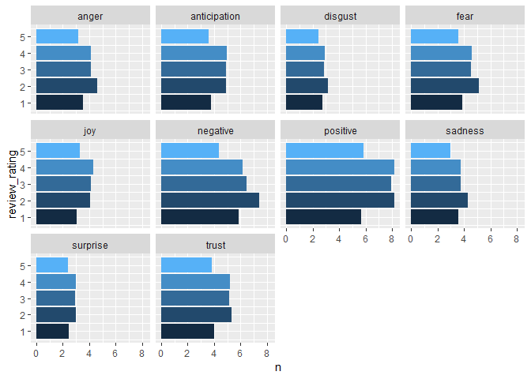

```r
videogame%>%
  group_by(id)%>%
  unnest_tokens(output = word, input = review)%>%
  inner_join(nrc)%>%
  group_by(id,sentiment,review_rating)%>%
  count()%>%
  group_by(sentiment, review_rating)%>%
  summarize(n = mean(n))%>%
  ungroup()%>%
  ggplot(aes(x=review_rating,y=n,fill=review_rating))+
  geom_col()+
  facet_wrap(~sentiment)+
  guides(fill=F)+coord_flip()
```

### Correlation between emotion expressed and review rating

Let us quantify the relationship by examining the correlation. Can you explain these results?

```r
videogame%>%
  group_by(id)%>%
  unnest_tokens(output = word, input = review)%>%
  inner_join(nrc)%>%
  group_by(id,sentiment,review_rating)%>%
  count()%>%
  ungroup()%>%
  group_by(sentiment)%>%
  summarize(correlation = cor(n,review_rating))
```

| sentiment | correlation |
| --- | --- |
| anger | -0.05581382 |
| anticipation | -0.06029752 |
| disgust | -0.04939535 |
| fear | -0.04775190 |
| joy | -0.03714383 |
| negative | -0.09129109 |
| positive | -0.04735236 |
| sadness | -0.06738403 |
| surprise | -0.04687779 |
| trust | -0.05741419 |

### Scatterplot of relationship

Let us examine scatterplots to gain a better understanding of the correlations.

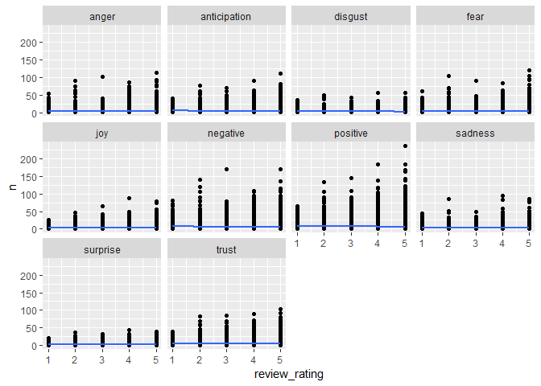

```r
videogame%>%
  group_by(id)%>%
  unnest_tokens(output = word, input = review)%>%
  inner_join(nrc)%>%
  group_by(id,sentiment,review_rating)%>%
  count()%>%
  ungroup()%>%
  group_by(sentiment)%>%
  ggplot(aes(x=review_rating,y=n))+geom_point()+facet_wrap(~sentiment)+geom_smooth(method='lm',se=F)
```

## afinn Lexicon

Let us examing the afinn lexicon that comes with library(tidytext). Here are the first 25 words of this lexicon

```r
as.data.frame(get_sentiments('afinn'))[1:25,]
```

|  | word | score |
| --- | --- | --- |
| 1 | abandon | -2 |
| 2 | abandoned | -2 |
| 3 | abandons | -2 |
| 4 | abducted | -2 |
| 5 | abduction | -2 |
| 6 | abductions | -2 |
| 7 | abhor | -3 |
| 8 | abhorred | -3 |
| 9 | abhorrent | -3 |
| 10 | abhors | -3 |

[output cut: 15 more lines]

Let us examine the scores used to represent these emotions

```r
get_sentiments('afinn') %>%
  group_by(score)%>%
  count()
```

| score | n |
| --- | --- |
| -5 | 16 |
| -4 | 43 |
| -3 | 264 |
| -2 | 965 |
| -1 | 309 |
| 0 | 1 |
| 1 | 208 |
| 2 | 448 |
| 3 | 172 |
| 4 | 45 |

[output cut: 1 more lines]

### Sentiment of Review 617

Now, let’s use this dictionary to determine the sentiment of review 617.

```r
videogame %>%
  select(id,review)%>%
  group_by(id)%>%
  unnest_tokens(output=word,input=review)%>%
  inner_join(get_sentiments('afinn'))%>%
  filter(id==617)%>%
  summarize(reviewSentiment = mean(score))
```

| id | reviewSentiment |
| --- | --- |
| 617 | 2.066667 |

Here is the review

```r
videogame$review[617]
```

```
## [1] "Like scottrocket3 said, you're out of your damn mind if you buy this for $200.  This is the best Mario game that ever came out.  The other is Super Mario World for Super Nintendo, also available for Nintendo DS.  I can't say enough about this great game!!  I LOVED the Super Mario Brothers Su…
```

### Next, we will examine the sentiment of all reviews.

```r
videogame %>%
  select(id,review)%>%
  group_by(id)%>%
  unnest_tokens(output=word,input=review)%>%
  inner_join(get_sentiments('afinn'))%>%
  summarize(reviewSentiment = mean(score))%>%
  ungroup()%>%
  summarize(min=min(reviewSentiment),max=max(reviewSentiment),median=median(reviewSentiment),mean=mean(reviewSentiment))
```

| min | max | median | mean |
| --- | --- | --- | --- |
| -4 | 5 | 1.444444 | 1.37611 |

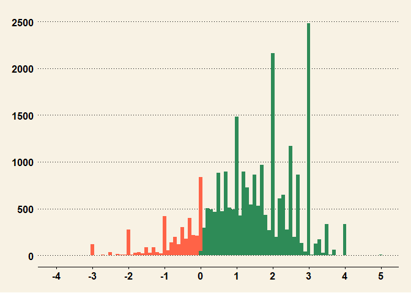

```r
videogame %>%
  select(id,review)%>%
  group_by(id)%>%
  unnest_tokens(output=word,input=review)%>%
  inner_join(get_sentiments('afinn'))%>%
  summarize(reviewSentiment = mean(score))%>%
  ungroup()%>%
  ggplot(aes(x=reviewSentiment,fill=reviewSentiment>0))+
  geom_histogram(binwidth = 0.1)+
  scale_x_continuous(breaks=seq(-5,5,1))+scale_fill_manual(values=c('tomato','seagreen'))+
  guides(fill=F)+
  theme_wsj()
```

## Jockers Lexicon

```r
library(lexicon)
head(key_sentiment_jockers)
```

|  | word | value |
| --- | --- | --- |
| 1 | abandon | -0.75 |
| 2 | abandoned | -0.50 |
| 3 | abandoner | -0.25 |
| 4 | abandonment | -0.25 |
| 5 | abandons | -1.00 |
| 6 | abducted | -1.00 |

Let us examine Reviews sentiment based on this lexicon

```r
videogame %>%
  select(id,review)%>%
  group_by(id)%>%
  unnest_tokens(output=word,input=review)%>%
  inner_join(key_sentiment_jockers)%>%
  summarize(reviewSentiment = mean(value))%>%
  ungroup()%>%
  summarize(min=min(reviewSentiment),max=max(reviewSentiment),median=median(reviewSentiment),mean=mean(reviewSentiment))
```

| min | max | median | mean |
| --- | --- | --- | --- |
| -1 | 1 | 0.2991525 | 0.2933024 |

Visualizing Sentiment scores

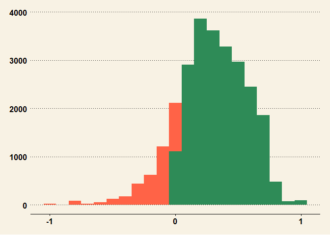

```r
videogame %>%
  select(id,review)%>%
  group_by(id)%>%
  unnest_tokens(output=word,input=review)%>%
  inner_join(key_sentiment_jockers)%>%
  summarize(reviewSentiment = mean(value))%>%
  ungroup()%>%
  ggplot(aes(x=reviewSentiment,fill=reviewSentiment>0))+
  geom_histogram(binwidth = 0.1)+
  scale_x_continuous(breaks=seq(-5,5,1))+scale_fill_manual(values=c('tomato','seagreen'))+
  guides(fill=F)+
  theme_wsj()
```

## Senticnet Lexicon

Examining yet another lexicon

```r
library(lexicon)
head(hash_sentiment_senticnet)
```

| x | y |
| --- | --- |
| aaa | 0.606 |
| aah | -0.510 |
| abandon | -0.560 |
| abandonment | -0.650 |
| abase | -0.580 |
| abasement | -0.580 |

Let us examine Reviews sentiment based on this lexicon

```r
videogame %>%
  select(id,review)%>%
  group_by(id)%>%
  unnest_tokens(output=word,input=review)%>%
  inner_join(hash_sentiment_senticnet, by = c('word'='x'))%>%
  summarize(reviewSentiment = mean(y))%>%
  ungroup()%>%
  summarize(min=min(reviewSentiment),max=max(reviewSentiment),median=median(reviewSentiment),mean=mean(reviewSentiment))
```

| min | max | median | mean |
| --- | --- | --- | --- |
| -0.86 | 0.909 | 0.08878472 | 0.09478637 |

Visualizing Sentiment scores

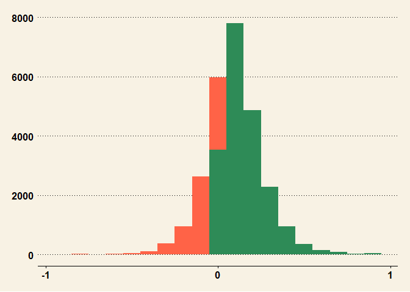

```r
videogame %>%
  select(id,review)%>%
  group_by(id)%>%
  unnest_tokens(output=word,input=review)%>%
  inner_join(hash_sentiment_senticnet, by = c('word'='x'))%>%
  summarize(reviewSentiment = mean(y))%>%
  ungroup()%>%
  ggplot(aes(x=reviewSentiment,fill=reviewSentiment>0))+
  geom_histogram(binwidth = 0.1)+
  scale_x_continuous(breaks=seq(-5,5,1))+scale_fill_manual(values=c('tomato','seagreen'))+
  guides(fill=F)+
  theme_wsj()
```

## Other Lexicons

There are of course many other lexicons.

```r
head(hash_sentiment_sentiword) # (2010)
```

| x | y |
| --- | --- |
| 365 days | -0.5000 |
| 366 days | 0.2500 |
| 3tc | -0.2500 |
| a fortiori | 0.2500 |
| a good deal | 0.2500 |
| a great deal | 0.3125 |

```r
hash_sentiment_socal_google
```

| x | y |
| --- | --- |
| a pillar | 2.904543116 |
| ab liva | -0.957870011 |
| able | 2.639373993 |
| above average | 3.215001812 |
| above mentioned | 2.581580349 |
| abrasive | 1.675191287 |
| absent | 0.485064882 |
| absolute | 0.473787953 |
| abstract | 2.006855726 |
| absurd | -3.777874410 |

[output cut: 3280 more lines]

```r
head(hash_sentiment_sentiword) # (2010)
```

| x | y |
| --- | --- |
| 365 days | -0.5000 |
| 366 days | 0.2500 |
| 3tc | -0.2500 |
| a fortiori | 0.2500 |
| a good deal | 0.2500 |
| a great deal | 0.3125 |

```r
hash_sentiment_slangsd
```

| x | y |
| --- | --- |
| a a | -0.5 |
| a bad amount of money | -0.5 |
| a bad mother | -0.5 |
| a bad taste in my mouth | -0.5 |
| a bag o' beagles | -0.5 |
| a bag of old and moldy ass | -0.5 |
| a barlow | -0.5 |
| a barney | -0.5 |
| a batman | 0.5 |
| a bitch | -0.5 |

[output cut: 9990 more lines]

```r
hash_sentiment_socal_google
```

| x | y |
| --- | --- |
| a pillar | 2.904543116 |
| ab liva | -0.957870011 |
| able | 2.639373993 |
| above average | 3.215001812 |
| above mentioned | 2.581580349 |
| abrasive | 1.675191287 |
| absent | 0.485064882 |
| absolute | 0.473787953 |
| abstract | 2.006855726 |
| absurd | -3.777874410 |

[output cut: 3280 more lines]

## Filter Lexicons

Under certain scenarios, one may want to filter out words such as when the words don’t add additional information or if they are offensive.

#### Here are a few lexicons that contain offensive words that one may want to use to filter out from one’s dataset.

- profanity_alvarez
- profanity_arr_bad
- profanity_banned
- profanity_racist
- profanity_zac_anger

To illustrate, here we are removing offensive words using two lexicons from videogame reviews

```r
videogame %>%
  group_by(id)%>%
  unnest_tokens(output = word, input = review)%>%
  anti_join(y = data.frame(word = c(profanity_banned, profanity_racist)),by=c('word'='word'))
```

| id | review_rating | word |
| --- | --- | --- |
| 1 | 1 | 1st |
| 1 | 1 | shipment |
| 1 | 1 | received |
| 1 | 1 | a |
| 1 | 1 | book |
| 1 | 1 | instead |
| 1 | 1 | of |
| 1 | 1 | the |
| 1 | 1 | game |
| 1 | 1 | 2nd |

[output cut: 9990 more lines]

## Wordcloud

In my opinion, wordclouds offer little insight into the data, yet they tend to be very good at capturing interest of non-technical audiences. Let us begin by creating a wordcloud from our data using library(tidytext), library(dplyr), library(tidyr),and library(wordcloud) functions.

[figure not shown]

```r
library(wordcloud)
wordcloudData =
  videogame%>%
  group_by(id)%>%
  unnest_tokens(output=word,input=review)%>%
  anti_join(stop_words)%>%
  group_by(word)%>%
  summarize(freq = n())%>%
  arrange(desc(freq))%>%
  ungroup()%>%
  data.frame()


library(wordcloud)
set.seed(617)
wordcloud(words = wordcloudData$word,wordcloudData$freq,scale=c(2,0.5),max.words = 100,colors=brewer.pal(9,"Spectral"))
```

### Comparison Cloud

Finally, here is a comparison cloud to contrast positive and negative words in the reviews.

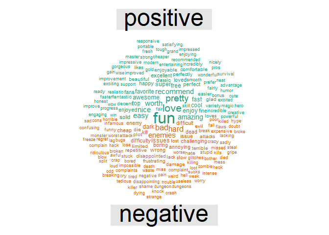

```r
library(tidyr)
wordcloudData =
  videogame%>%
  group_by(id)%>%
  unnest_tokens(output=word,input=review)%>%
  anti_join(stop_words)%>%
  inner_join(get_sentiments('bing'))%>%
  ungroup()%>%
  count(sentiment,word,sort=T)%>%
  spread(key=sentiment,value = n,fill=0)%>%
  data.frame()
rownames(wordcloudData) = wordcloudData[,'word']
wordcloudData = wordcloudData[,c('positive','negative')]
set.seed(617)
comparison.cloud(term.matrix = wordcloudData,scale = c(2,0.5),max.words = 200, rot.per=0)
```